Summary of significant and non-significant differences in metrics

**Reference level: head**; random intercepts for Id and Date, random slopes for wearing position

Metric

Mean error

Standard deviation (SD)

Boxplot

Intraclass correlation (ICC)

Chest

Wrist

Id

Chest<sup>1</sup>

Wrist<sup>1</sup>

Date<sup>1</sup>

Residual

Id

Chest<sup>1</sup>

Wrist<sup>1</sup>

Date<sup>1</sup>

Residual

Grand minimum (abs)

1%

0%

0%

1%

1%

3%

6%

0%

0%

0%

6%

10%

Grand median (abs)

4%

5%

14%

15%

12%

39%

34%

11%

6%

8%

40%

26%

Grand maximum (abs)

524%

619%

283%

1,445%

1,742%

2,936%

3,254%

69%

20%

35%

75%

68%

None differ significantly from head:

Median (abs)

3%

4%

18%

17%

17%

41%

31%

13%

7%

11%

38%

26%

Period above threshold

period above 250

−9%

−21%

82%

41%

64%

56%

59%

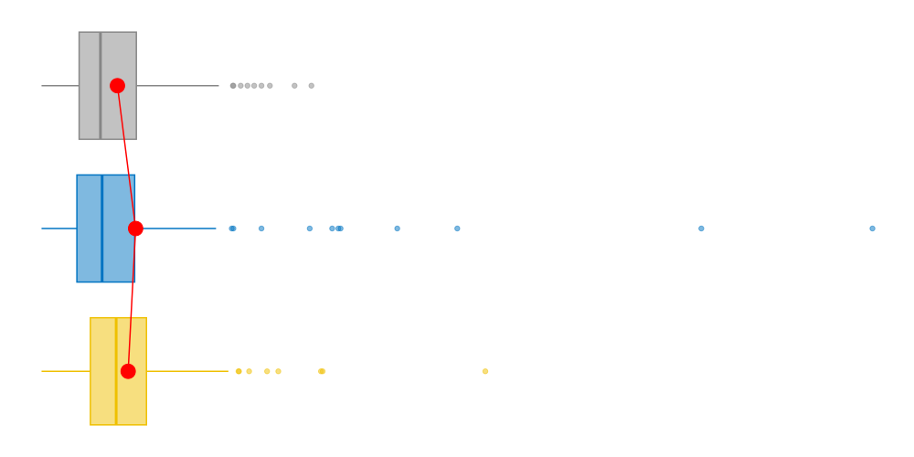

35%

9%

21%

17%

18%

Pulses above threshold

mean duration pulses above 250

−7%

−23%

43%

25%

30%

48%

53%

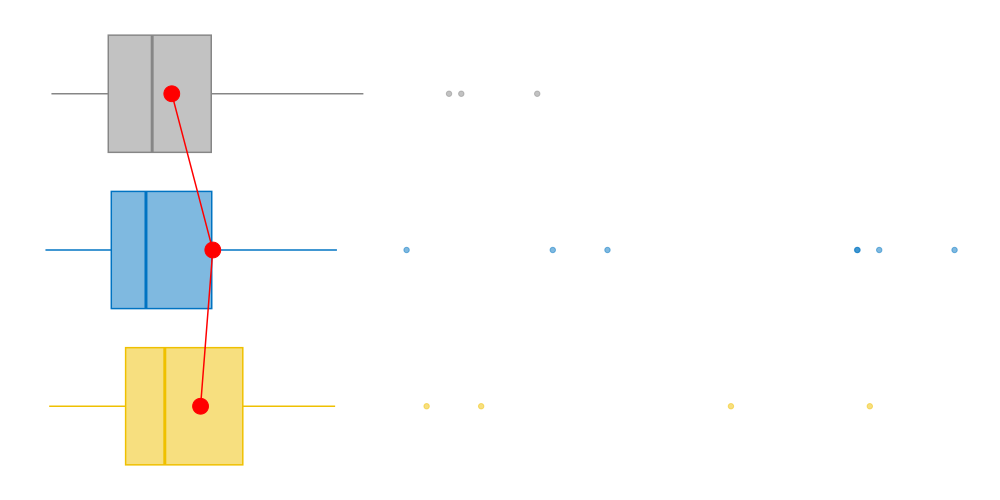

22%

7%

11%

27%

33%

Barroso

bright threshold

−18%

−4%

95%

63%

64%

96%

78%

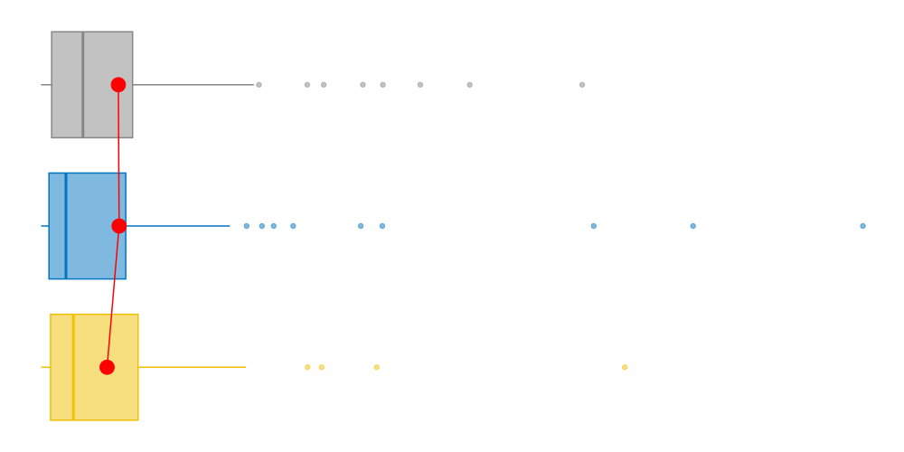

28%

12%

13%

28%

19%

Interdaily_stability

interdaily stability

−8%

−5%

21%

—

—

—

14%

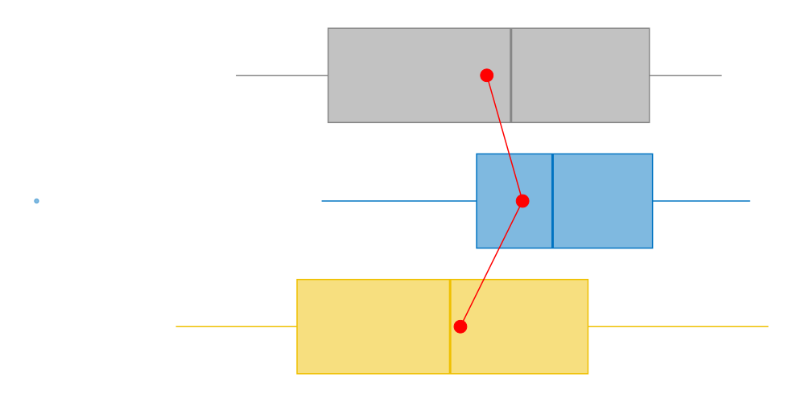

69%

—

—

—

31%

M5

darkest 5h mean

−5%

−7%

0%

−5%

−10%

−13%

−17%

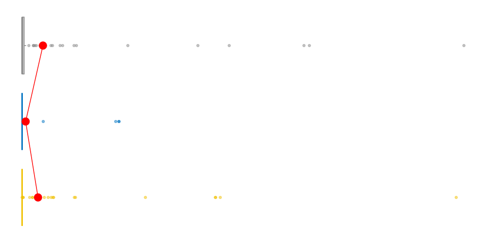

0%

5%

17%

30%

48%

Barroso

bright mean level

−10%

−1%

92%

80%

60%

159%

108%

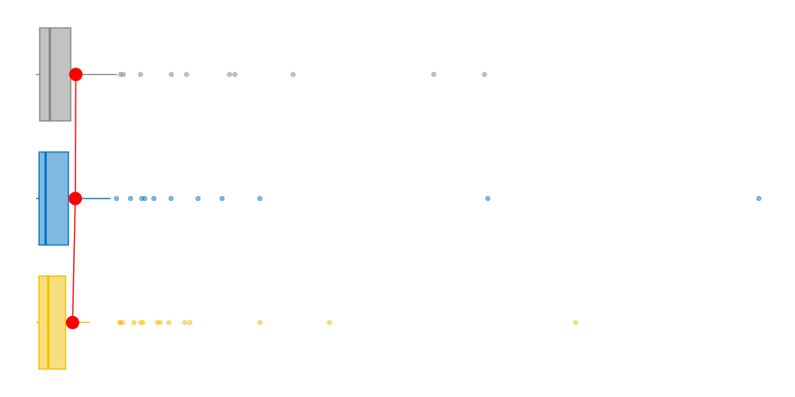

15%

12%

6%

45%

21%

Period above threshold

period above 1000

2%

−9%

46%

29%

38%

57%

83%

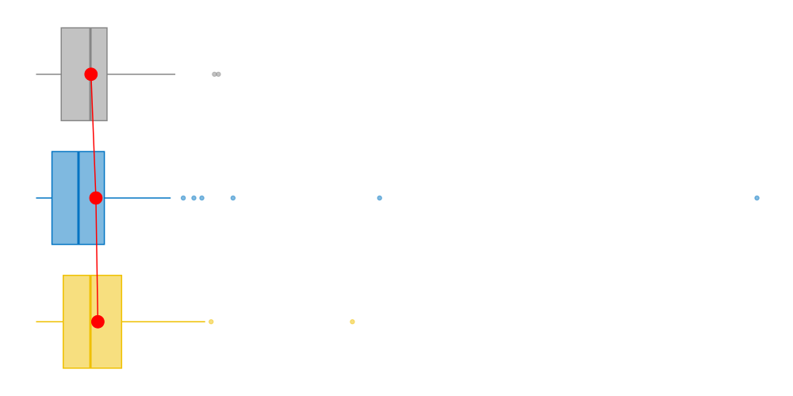

15%

6%

10%

22%

47%

Midpoint cumulative exposure

midpointCE

−3%

−3%

6%

4%

4%

14%

9%

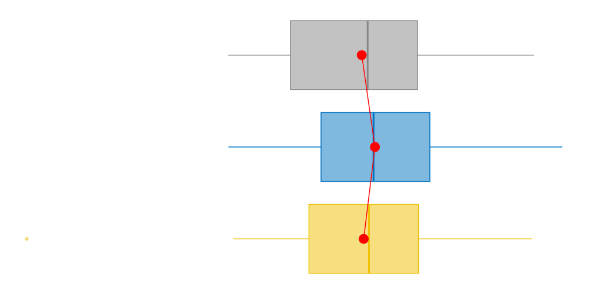

10%

4%

5%

55%

25%

Barroso

circadian variation

−3%

0%

9%

31%

33%

53%

44%

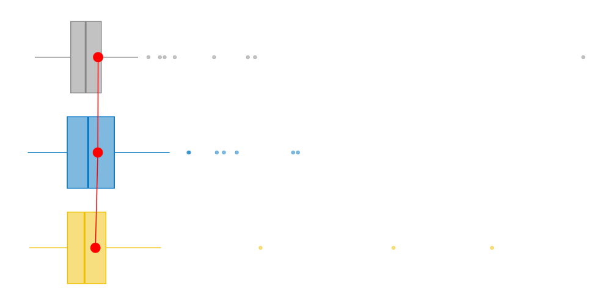

1%

14%

16%

41%

28%

Centroid of light exposure

centroidLE

−1%

−1%

3%

3%

4%

12%

6%

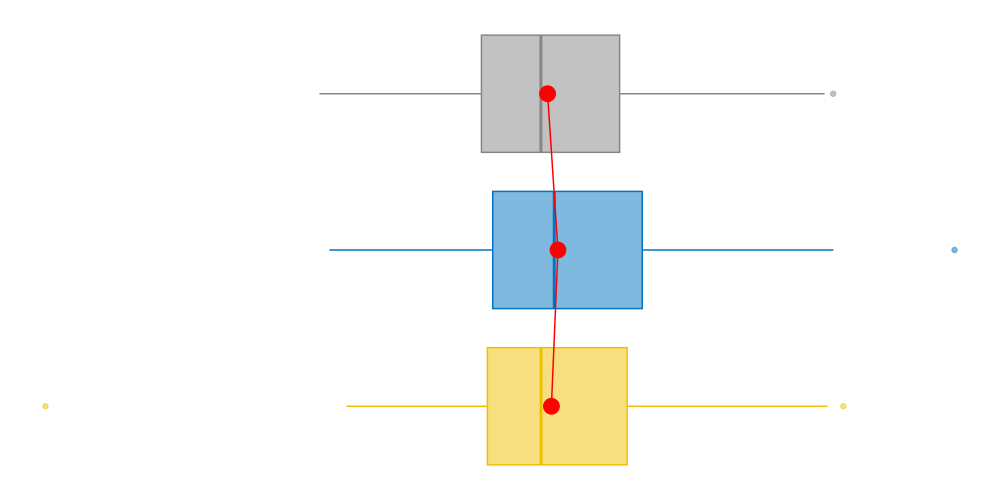

5%

5%

6%

64%

20%

Barroso

bright cluster

−4%

3%

162%

17%

1%

173%

143%

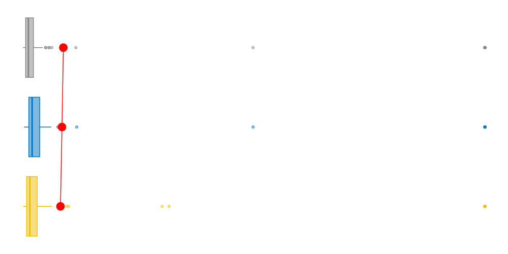

34%

0%

0%

39%

27%

Timing above threshold

mean timing above 10

1%

−0%

5%

4%

5%

9%

8%

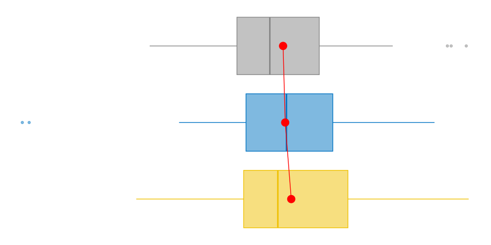

11%

6%

12%

38%

32%

L10

brightest 10h offset

1%

−0%

5%

7%

6%

6%

8%

11%

20%

18%

19%

32%

L10

brightest 10h midpoint

2%

−0%

7%

9%

8%

9%

11%

11%

20%

18%

19%

32%

L10

brightest 10h onset

2%

−0%

11%

15%

14%

14%

18%

11%

20%

18%

19%

32%

L10

brightest 10h mean

1%

3%

38%

17%

17%

41%

21%

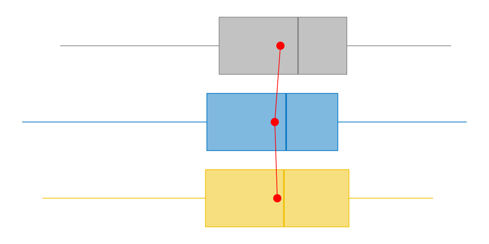

35%

7%

7%

40%

11%

Timing above threshold

mean timing above 1000

3%

2%

3%

5%

6%

13%

6%

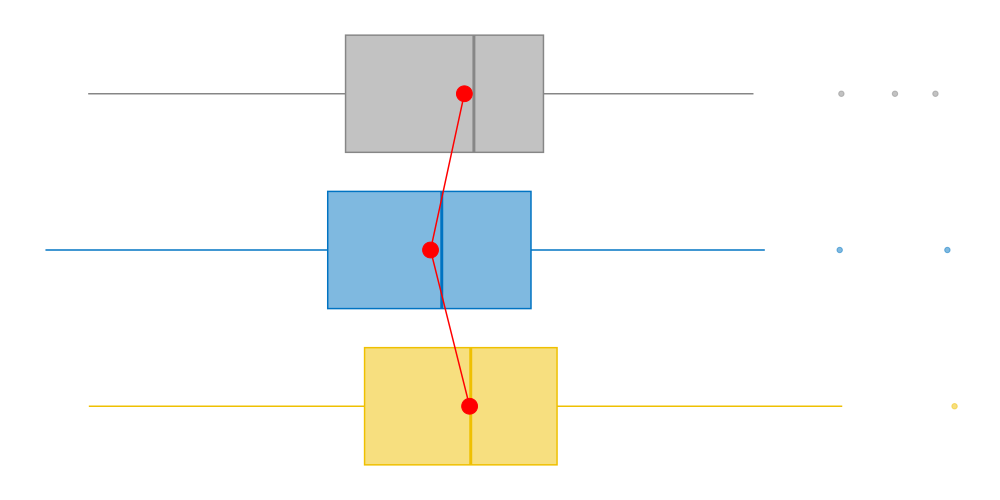

4%

9%

14%

61%

12%

Intradaily variability

intradaily variability

2%

3%

11%

4%

6%

26%

20%

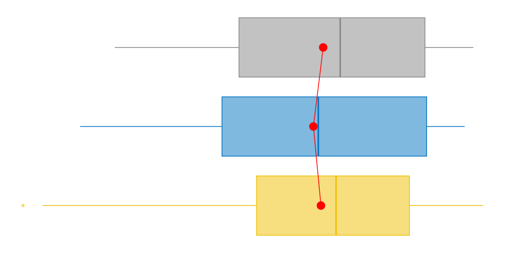

9%

2%

3%

54%

32%

Timing above threshold

last timing above 1000

4%

4%

8%

8%

9%

11%

6%

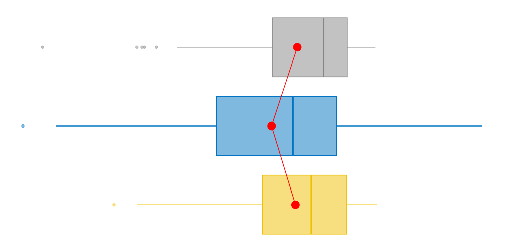

18%

17%

21%

34%

10%

M5

darkest 5h offset

1%

8%

16%

25%

20%

32%

34%

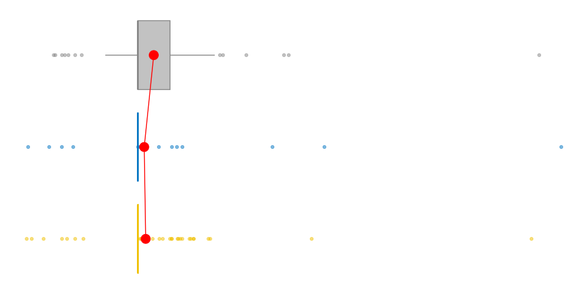

7%

19%

12%

29%

33%

Pulses above threshold

total duration pulses above 250

3%

9%

44%

16%

18%

74%

40%

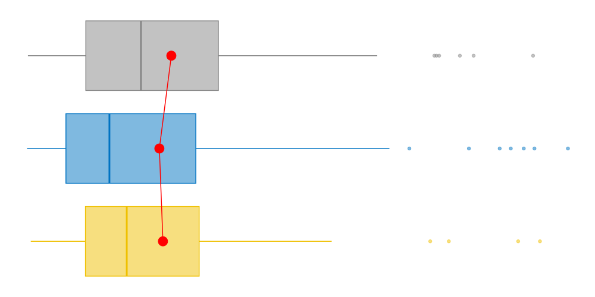

20%

3%

3%

57%

17%

Time above threshold

duration above 10

4%

9%

33%

17%

11%

34%

21%

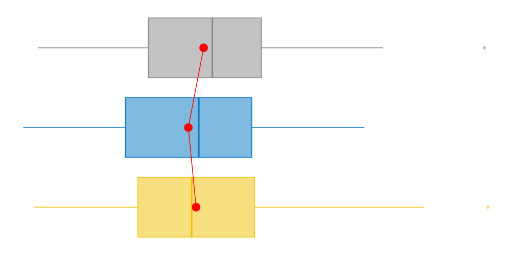

35%

10%

4%

37%

15%

Time above threshold

duration above 250

2%

16%

46%

13%

17%

80%

44%

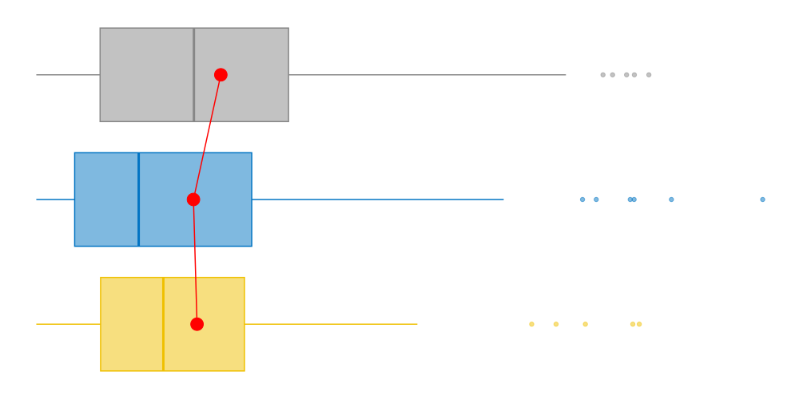

20%

2%

3%

58%

17%

Mean nvRD

nvRD

6%

15%

40%

18%

22%

50%

27%

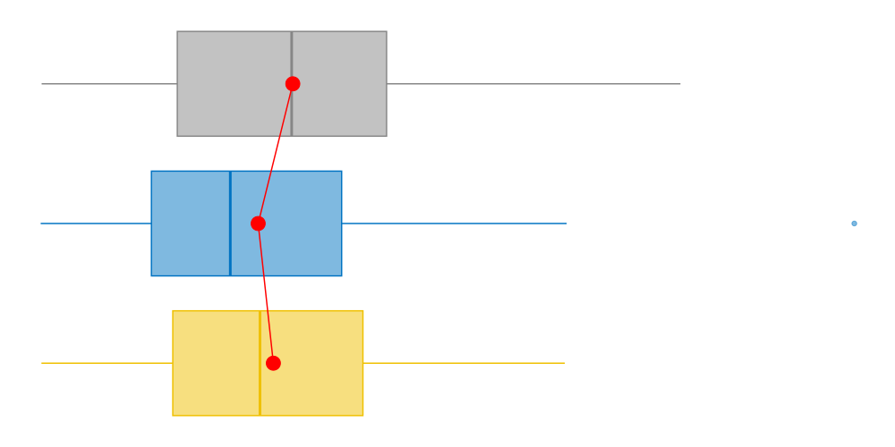

28%

6%

8%

45%

13%

Pulses above threshold

mean duration pulses above 1000

11%

12%

14%

9%

35%

40%

44%

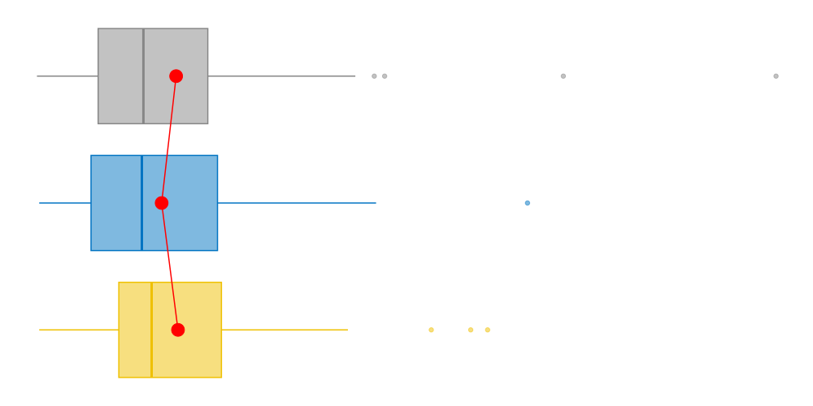

4%

2%

24%

31%

38%

Light dose

dose

17%

7%

51%

32%

25%

78%

60%

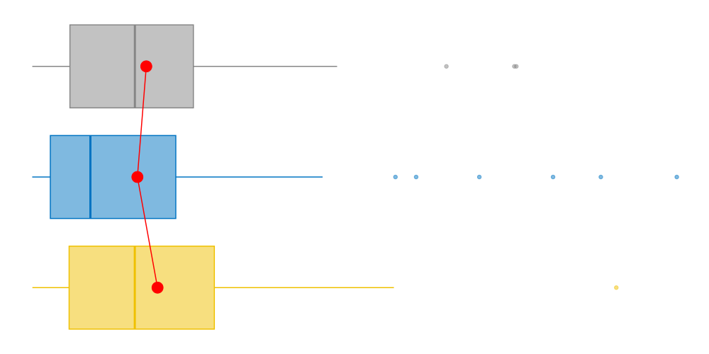

18%

8%

4%

44%

26%

Barroso

dark threshold

127%

162%

283%

254%

337%

974%

590%

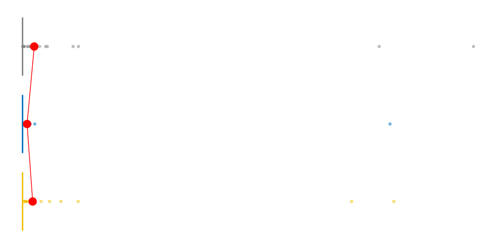

5%

4%

7%

61%

22%

Barroso

dark mean level

524%

619%

0%

1,445%

1,742%

2,936%

3,254%

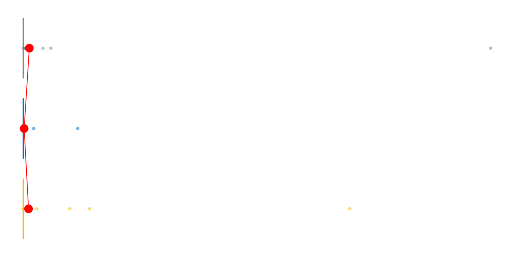

0%

9%

12%

35%

44%

Only chest differs significantly from head position:

Median (abs)

4%

2%

2%

4%

3%

13%

7%

2%

5%

3%

70%

20%

Pulses above threshold

mean onset pulses above 1000

4%

2%

2%

4%

3%

13%

7%

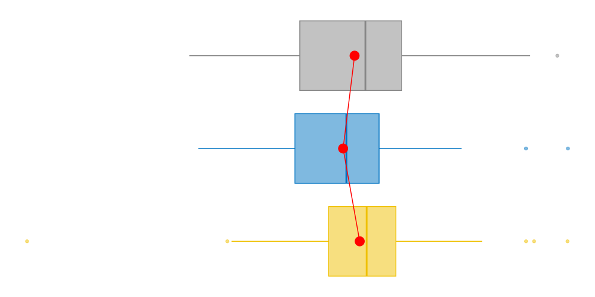

2%

5%

3%

70%

20%

Pulses above threshold

mean midpoint pulses above 1000

4%

2%

2%

4%

3%

13%

7%

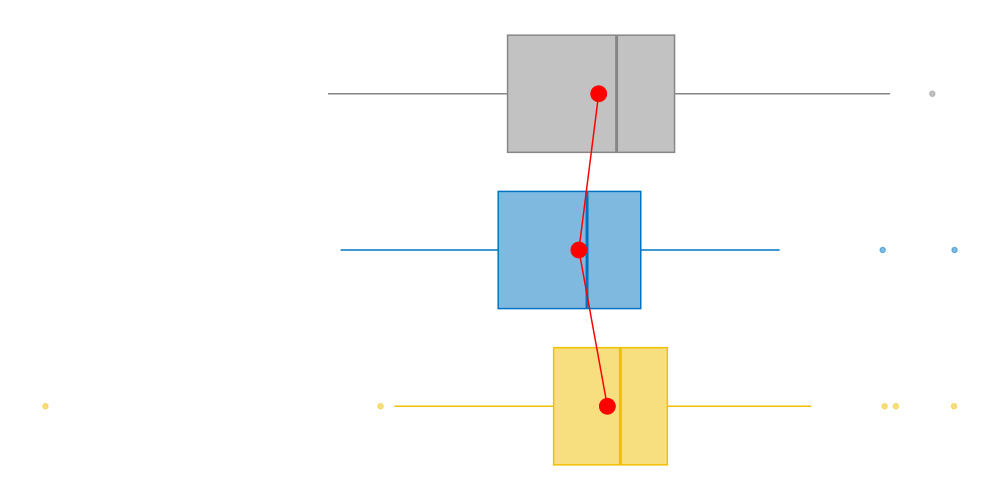

2%

5%

2%

71%

20%

Pulses above threshold

mean offset pulses above 1000

4%

3%

2%

3%

2%

13%

7%

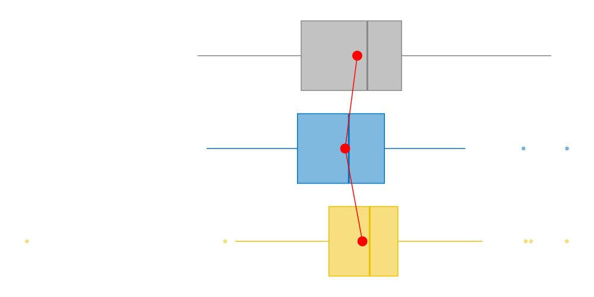

2%

5%

2%

71%

20%

Pulses above threshold

mean level pulses above 250

27%

−0%

8%

28%

25%

61%

46%

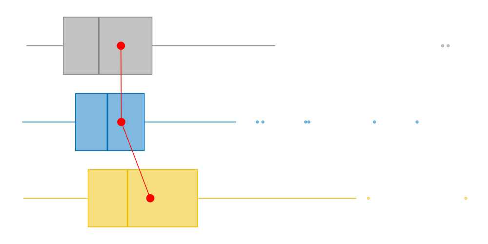

1%

11%

9%

50%

29%

Pulses above threshold

mean level pulses above 1000

24%

5%

32%

7%

23%

39%

36%

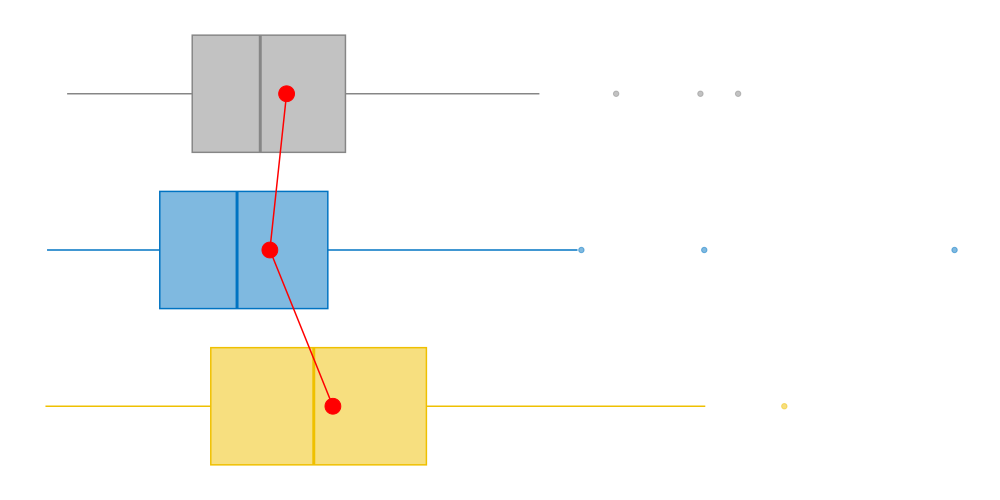

22%

1%

12%

35%

30%

Only wrist differs significantly from head position:

Median (abs)

14%